# MCML analysis of coded discussion interactions

# 9. Visualisation

`cograph::splot()` renders any netobject. Use it on the macro for the cluster-of-clusters view and on a within-cluster netobject for the fine-grained view.

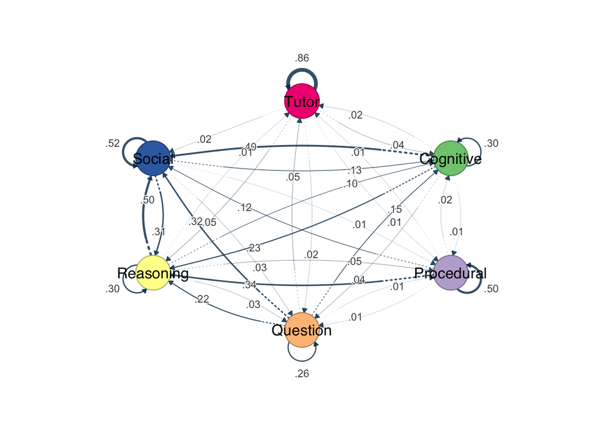

```r
cograph::splot(MCMLL_tna$macro,
               edge_labels = TRUE,
               edge_label_size = 0.7)
```

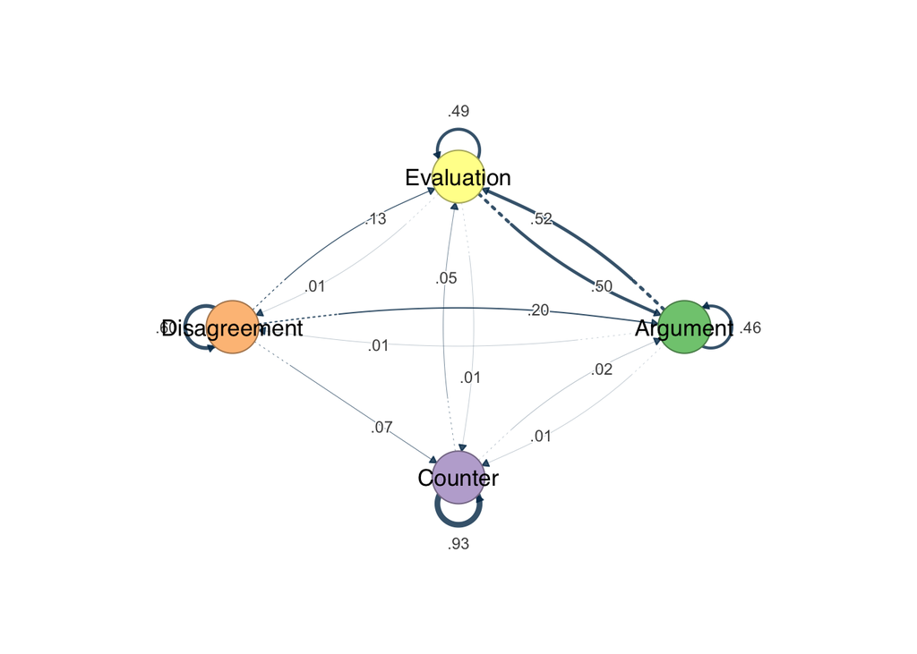

```r
cograph::splot(MCMLL_tna$Cognitive,
               edge_labels = TRUE,
               edge_label_size = 0.7)
```

# 10. What to read off this analysis

- **Macro diagonal vs off-diagonal**: how cluster-bound the discussion is. A high `Reasoning -> Reasoning` value means reasoning utterances are followed by more reasoning, not by social or procedural follow-ups.
- **Macro inits**: which cluster opens sessions. If the discussion is Tutor-initiated, expect a high `Tutor` init.
- **Bootstrap CIs**: a wide CI on a macro edge tells you the cluster-level flow is sensitive to which actors / sessions you sample. Narrow CIs with stars are the stable interactions worth interpreting.
- **Within-cluster networks**: the conditional dynamics inside each cluster, useful for fine-grained pedagogical claims (e.g. `Argument -> Counter-argument` rates inside Cognitive).
- **Centralities**: at the macro level, an outgoing-strength hub is a cluster the discussion frequently leaves; an incoming hub is a cluster it frequently lands in.